# Linear regression

# introduction

This short handout takes you through linear regression. Go through the material, typing the R commands at the R prompt, making sure you understand the content. There are some tasks at the end.

Remember that you can type `?lm` at the R prompt to get help on linear regression.

# Linear regression: trees.

The R system includes a dataset called `trees`:

```r
data(trees)
head(trees)
```

```
##   Girth Height Volume
## 1   8.3     70   10.3
## 2   8.6     65   10.3
## 3   8.8     63   10.2
## 4  10.5     72   16.4
## 5  10.7     81   18.8
## 6  10.8     83   19.7
```

We will use linear regression to analyse this dataset. We will start by analysing the dependency of volume on tree height; The first step is to plot a scattergraph:

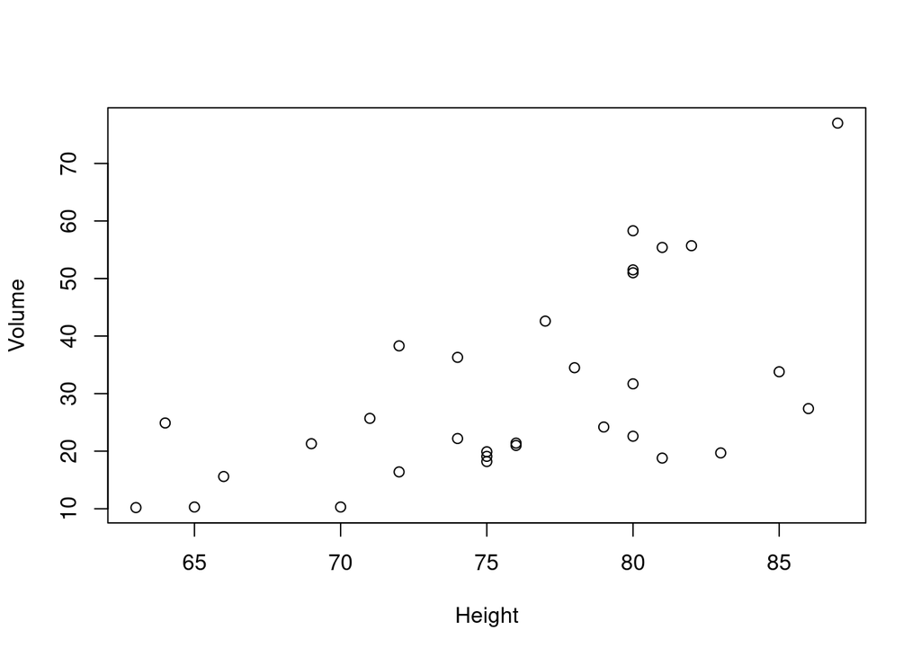

```r
plot(Volume~Height,data=trees)
```

The points are reasonably scattered, without any outliers or nonlinearity. The points are showing broadly uniform variance about a line, although there is a suggestion that the variance increases as we move rightwards along the x-axis. We can use R to calculate the best-fit line using the `lm()` function:

```r
lm(Volume~Height,data=trees)
```

```
##
## Call:
## lm(formula = Volume ~ Height, data = trees)
##
## Coefficients:
## (Intercept)       Height
##     -87.124        1.543
```

This shows that the relation is approximately

$$V = -87.124 + 1.543H$$

We can get more information by using the `summary()` command:

```r
fit <- lm(Volume~Height,data=trees)
summary(fit)
```

```
##
## Call:
## lm(formula = Volume ~ Height, data = trees)
##
## Residuals:
##     Min      1Q  Median      3Q     Max
## -21.274  -9.894  -2.894  12.068  29.852
##
## Coefficients:
##             Estimate Std. Error t value Pr(>|t|)
## (Intercept) -87.1236    29.2731  -2.976 0.005835 **
## Height        1.5433     0.3839   4.021 0.000378 ***
## ---
## Signif. codes:  0 '***' 0.001 '**' 0.01 '*' 0.05 '.' 0.1 ' ' 1
##
## Residual standard error: 13.4 on 29 degrees of freedom
## Multiple R-squared:  0.3579, Adjusted R-squared:  0.3358
## F-statistic: 16.16 on 1 and 29 DF,  p-value: 0.0003784
```

This gives more information such as p-values and standard errors. For example, the slope is 1.5433 (estimated) but with an error of $\pm 0.3839$.

We can plot the regression line on the scattergraph as follows.

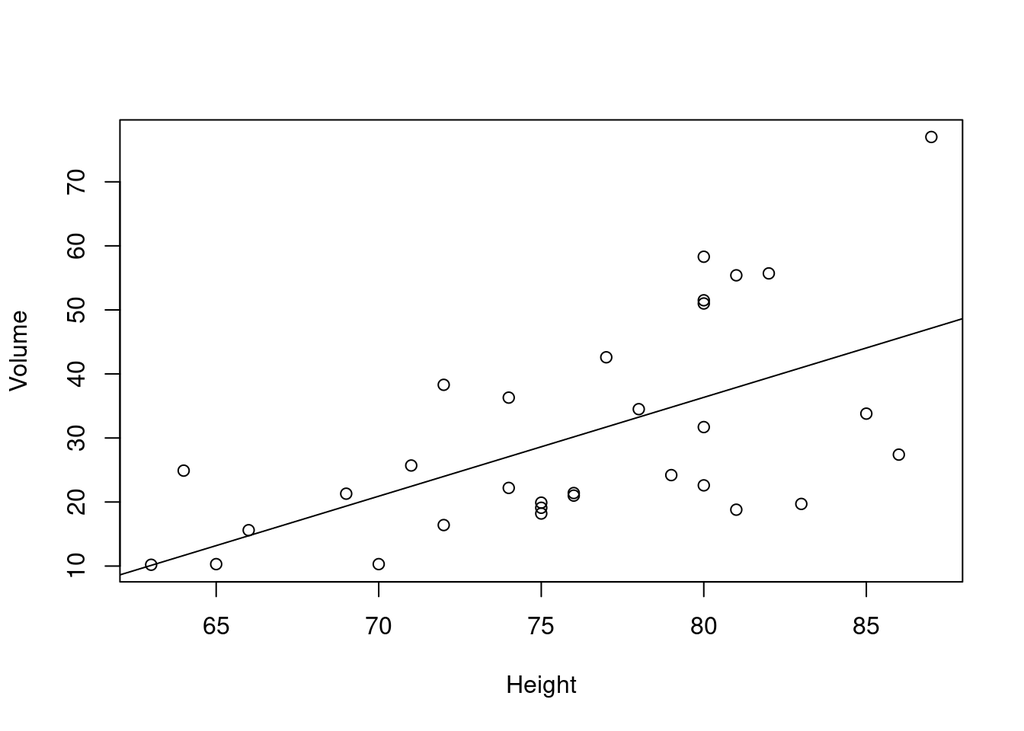

```r
plot(Volume~Height,data=trees)
abline(fit)
```

However, this model has a serious defect in that short trees are predicted to have negative volumes, an absurdity. We can mitigate this defect by using a logarithmic transform:

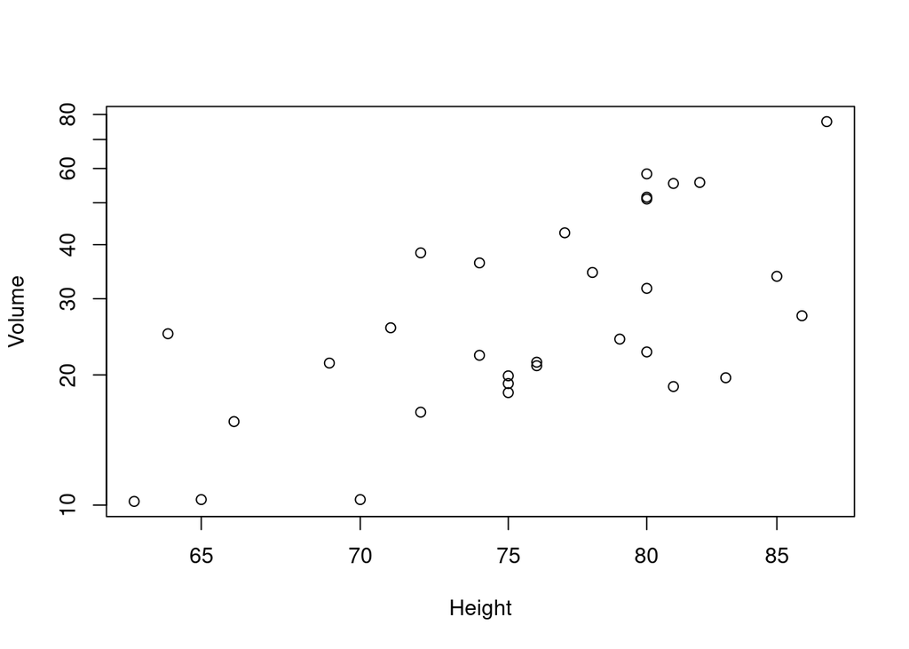

```r
plot(Volume~Height, data=trees, log='xy')
```

However, `abline()` does not work with this type of plot, so we will have to work manually:

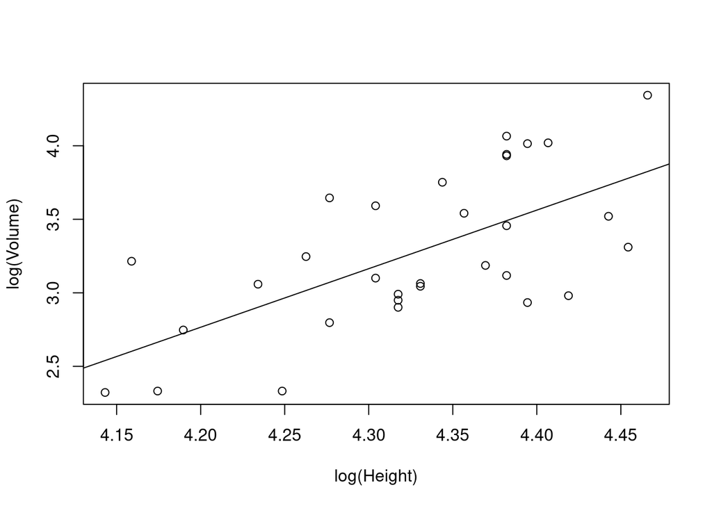

```r
plot(log(Volume)~log(Height),data=trees)
logfit <- lm(log(Volume)~log(Height),data=trees)
abline(logfit)
```

And to see the details we use `summary()`:

```r
summary(logfit)
```

```
##
## Call:
## lm(formula = log(Volume) ~ log(Height), data = trees)
##
## Residuals:
##      Min       1Q   Median       3Q      Max
## -0.65691 -0.27917 -0.08039  0.42193  0.61252
##
## Coefficients:
##             Estimate Std. Error t value Pr(>|t|)
## (Intercept) -13.9587     3.7553  -3.717 0.000857 ***
## log(Height)   3.9821     0.8677   4.589 7.93e-05 ***
## ---
## Signif. codes:  0 '***' 0.001 '**' 0.01 '*' 0.05 '.' 0.1 ' ' 1
##
## Residual standard error: 0.4074 on 29 degrees of freedom
## Multiple R-squared:  0.4207, Adjusted R-squared:  0.4008
## F-statistic: 21.06 on 1 and 29 DF,  p-value: 7.928e-05
```

## Using Girth instead

The girth of the tree is a more useful predictor than height:

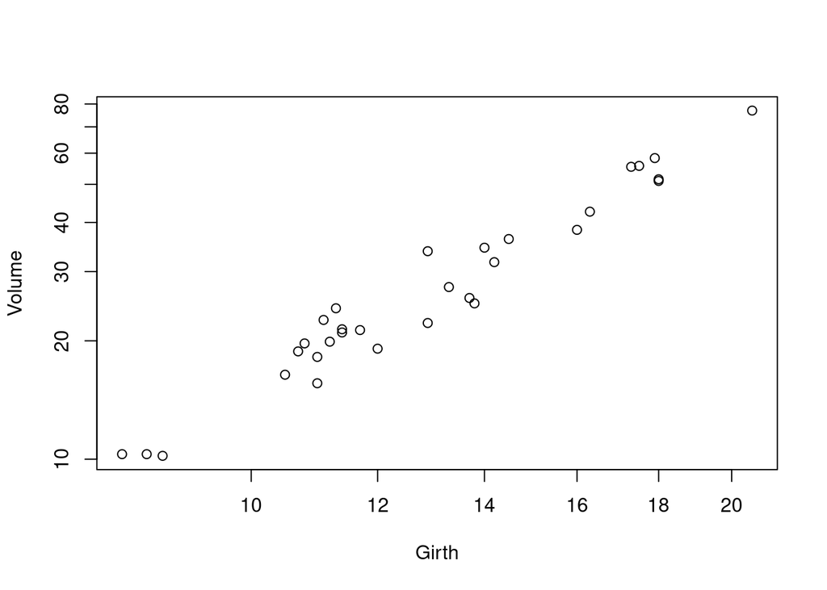

```r
plot(Volume~Girth,data=trees,log='xy')
```

We can try linear regression:

```r
logfit2 <- lm(log(Volume)~log(Girth),data=trees)
summary(logfit2)
```

```
##
## Call:
## lm(formula = log(Volume) ~ log(Girth), data = trees)
##
## Residuals:
##       Min        1Q    Median        3Q       Max
## -0.205999 -0.068702  0.001011  0.072585  0.247963
##
## Coefficients:
##             Estimate Std. Error t value Pr(>|t|)
## (Intercept) -2.35332    0.23066  -10.20 4.18e-11 ***
## log(Girth)   2.19997    0.08983   24.49  < 2e-16 ***
## ---
## Signif. codes:  0 '***' 0.001 '**' 0.01 '*' 0.05 '.' 0.1 ' ' 1
##
## Residual standard error: 0.115 on 29 degrees of freedom
## Multiple R-squared:  0.9539, Adjusted R-squared:  0.9523
## F-statistic: 599.7 on 1 and 29 DF,  p-value: < 2.2e-16
```

See how the R-squared value is higher than the previous analyses. But, the plot is more convincing than the numbers, IMHO:

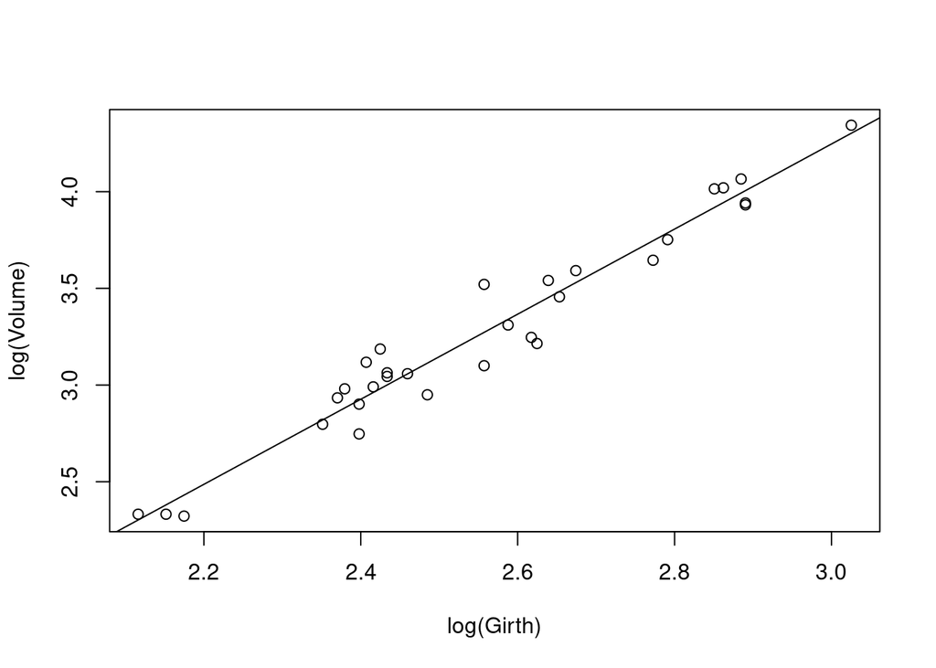

```r
plot(log(Volume)~log(Girth),data=trees)
abline(logfit2)
```

It is possible to use both height and weight together as regressors:

```r
summary(lm(Volume ~ Girth + Height, data=trees))
```

```
##
## Call:
## lm(formula = Volume ~ Girth + Height, data = trees)
##
## Residuals:
##     Min      1Q  Median      3Q     Max
## -6.4065 -2.6493 -0.2876  2.2003  8.4847
##
## Coefficients:
##             Estimate Std. Error t value Pr(>|t|)
## (Intercept) -57.9877     8.6382  -6.713 2.75e-07 ***
## Girth         4.7082     0.2643  17.816  < 2e-16 ***
## Height        0.3393     0.1302   2.607   0.0145 *
## ---
## Signif. codes:  0 '***' 0.001 '**' 0.01 '*' 0.05 '.' 0.1 ' ' 1
##
## Residual standard error: 3.882 on 28 degrees of freedom
## Multiple R-squared:  0.948,  Adjusted R-squared:  0.9442
## F-statistic:   255 on 2 and 28 DF,  p-value: < 2.2e-16
```

This would mean that $V = -57.9877 + 4.7082G + 0.3393H$. Again the model has a defect that small trees are predicted to have negative volume. So it might be better to use logarithmic transformation:

```r
summary(lm(log(Volume) ~ log(Girth) + log(Height), data=trees))
```

```
##
## Call:
## lm(formula = log(Volume) ~ log(Girth) + log(Height), data = trees)
##
## Residuals:
##       Min        1Q    Median        3Q       Max
## -0.168561 -0.048488  0.002431  0.063637  0.129223
##
## Coefficients:
##             Estimate Std. Error t value Pr(>|t|)
## (Intercept) -6.63162    0.79979  -8.292 5.06e-09 ***
## log(Girth)   1.98265    0.07501  26.432  < 2e-16 ***
## log(Height)  1.11712    0.20444   5.464 7.81e-06 ***
## ---
## Signif. codes:  0 '***' 0.001 '**' 0.01 '*' 0.05 '.' 0.1 ' ' 1
##
## Residual standard error: 0.08139 on 28 degrees of freedom
## Multiple R-squared:  0.9777, Adjusted R-squared:  0.9761
## F-statistic: 613.2 on 2 and 28 DF,  p-value: < 2.2e-16
```

This would mean that $\log V = -6.63 + 1.98\log G + 1.117\log H$, or $V = e^{-6.63}G^{1.98}H^{1.117}$.

If the height and weight have combined effects we can use the star operator:

```r
summary(lm(log(Volume) ~ log(Girth) * log(Height), data=trees))
```

```
##
## Call:
## lm(formula = log(Volume) ~ log(Girth) * log(Height), data = trees)
##
## Residuals:
##       Min        1Q    Median        3Q       Max
## -0.165941 -0.048613  0.006384  0.062204  0.132295
##
## Coefficients:
##                        Estimate Std. Error t value Pr(>|t|)
## (Intercept)             -3.6869     7.6996  -0.479    0.636
## log(Girth)               0.7942     3.0910   0.257    0.799
## log(Height)              0.4377     1.7788   0.246    0.808
## log(Girth):log(Height)   0.2740     0.7124   0.385    0.704
##
## Residual standard error: 0.08265 on 27 degrees of freedom
## Multiple R-squared:  0.9778, Adjusted R-squared:  0.9753
## F-statistic: 396.4 on 3 and 27 DF,  p-value: < 2.2e-16
```

This would indicate that $\log V = -3.68 + 0.79\log G + 0.43\log H + 0.27\log G*\log H$. Do you think this is a better model?

# Your Tasks

## Task 1: Height-weight analysis

Download file `heightweight.txt` from canvas and load it into R, using

`a <- read.table(file.choose(),header=TRUE)`

Then use commands such as

`plot(weight~height,data=a)`

to produce a scattergraphs.

What is the predicted weight of someone with a height of 2m exactly? What is the predicted weight of someone with a height of 0m exactly? Is this a sensible question? Does it have a sensible answer?

Now produce a few different scattergraphs, maybe logarithmically transformed.

## Task 2: econometric dataset

Download the file `e3mg.txt` from canvas and load it using

`e3mg <- read.table(file.choose(),header=TRUE)`

The first five columns are economic variables which can be controlled politically [at least, some economists believe so]. The values are normalized to lie in a standardised range. Columns `rec_dep` and `rec_len` are the length and depth of the resulting recession. We will use linear regression to predict `rec_dep` as a function of the five independent variables.

- Using idiom like `summary(lm(rec_dep~oil.price + direct.tax + interest.rate, data=e3mg)`, fit a regression model to all five independent variables.
- By adding and removing variables judiciously, find the best model you can. Here “best” means the best combination of simplicity and accuracy.

## Task 3: portfolio

You should by now have a small dataset which you are analysing for your portfolio. Apply linear regression to it and discuss your results.

## Task 4: swiss dataset

The `swiss` dataset is an R builtin. Type `swiss` at the R commandline to see it, and `?swiss` to see some documentation. Try to predict infant mortality as a function of the other variables.

(note: be careful with case sensitivity, eg. `Infant.Mortality` rather than `infant.Mortality` or `infant.mortality`).